# IT Army of Ukraine

statistics

final project

IT Army of Ukraine

DACSS 603 Final Project Work: “Analyzing Trends With IT Army of Ukraine”

Kristina Becvar https://www.kristinabecvar.com  
2022-04-20

# Data Sources

## DDOS User Observations

The primary data is a set of observations of users of a novice “hacking tool” to engage in DDOS (denial of service) attacks against Russian targets in March 2022. The data contains a total of users cumulatively for each day of the series March 2 through March 11, and the users represent participants from 98 counties.

## WVS/EVS

I will also be using a data set of observations from the World Values Survey conducted from 2017-2021 as a joint project between the World Values Survey and the European Values Studies. This data was released in July 2021, and contains responses from ~135,000 respondents among 95 countries.

## Spike/Newswhip

The third is a data set of media coverage (media articles and social media mentions) of the Ukrainian minister’s call for volunteers for the “IT Army of Ukraine” to help fight the invasion of Russia on the digital front.

# Background

## Gathering Spike/Newswhip Data

# Hypothesis

I am looking at a model where the outcome is the number of DDOS attacks originated from a given country and explanatory variables are WVS activism scores, media coverage, and other controls.

# Data Analysis

## DDOS Users

The data I imported for this first exploration is a data frame consisting of 98 observations with the columns:

- Country Name
- Population (as indicated by the U.S. CIA World factbook website)
- Region (as indicated by the UN classifications)
- Cumulative total number of users of the DDOS attack tool from each representative country as of March 11, 2022

```
   Country            Population            Region
 Length:98          Min.   :     29789   Length:98
 Class :character   1st Qu.:   4948116   Class :character
 Mode  :character   Median :  11768856   Mode  :character
                    Mean   :  65170210
                    3rd Qu.:  45576742
                    Max.   :1397897720
     Users
 Min.   :    1.00
 1st Qu.:    7.25
 Median :   55.00
 Mean   :  498.76
 3rd Qu.:  214.00
 Max.   :13186.00
```

```
# A tibble: 6 x 13
  Country  Population Region March2 March3 March4 March5 March6 March7
  <chr>         <dbl> <chr>   <dbl>  <dbl>  <dbl>  <dbl>  <dbl>  <dbl>
1 Aland         29789 North~      1      1      1      1      1      1
2 Albania     3088385 South~     19     22     22     23     32     44
3 Algeria    43576691 North~      0      8      8      8      8      8
4 Andorra       85645 South~      2      6      6      6      6      6
5 Argenti~   45864941 South~      9      9      9     11     11     11
6 Armenia     3011609 Weste~      1      7      7      9      9     13
# ... with 4 more variables: March8 <dbl>, March9 <dbl>,
#   March10 <dbl>, March11 <dbl>
```

The total DDOS users as of the first day of observations, March 2, 2022, and the last day available for observation, March 11, 2022 began at 7,850 and grew to a total of 48,879.

```
[1] 7850
```

```
[1] 48879
```

However, I am not going to examine the panel data; I am only going to look at the cumulative data - or the count of users on the last day of observations, March 11.

Plot the relationships between key variables of this dataset:

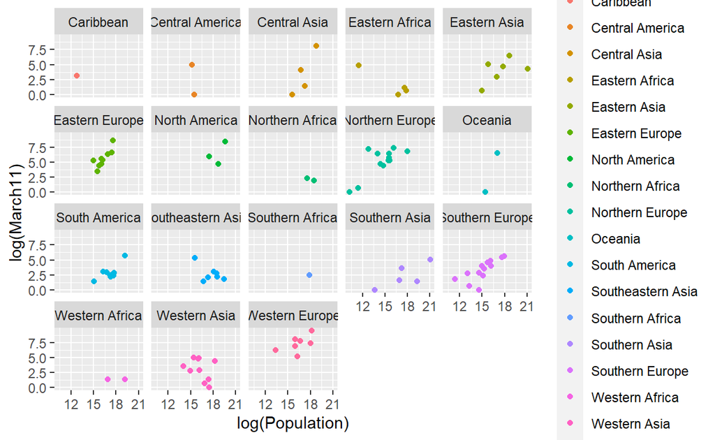

What I want to look at is the linear model of the relationship between the population of each country with participating users and the corresponding sample of users from that country.

I want to first simplify my data set

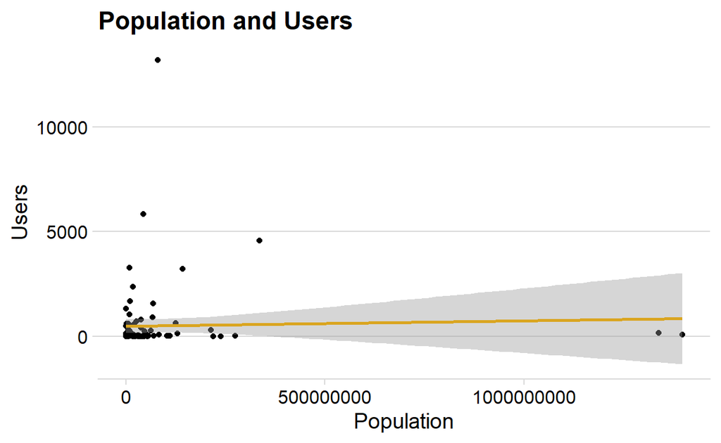

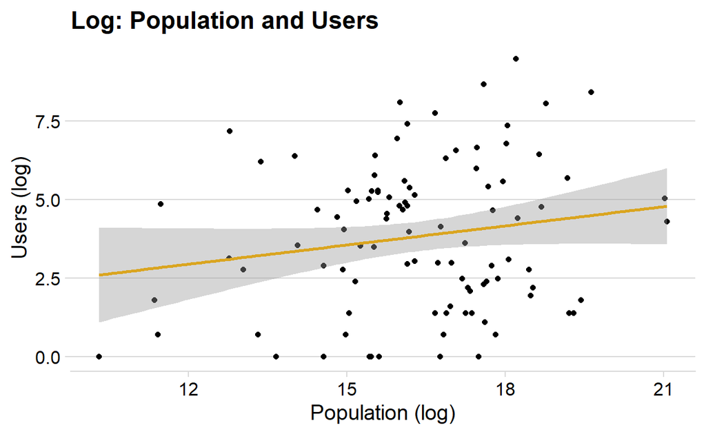

The next data source I want to incorporate is the IVS data set. This brings in an overwhelming 135,000 observations of 231 variables.

```
# A tibble: 6 x 10
  gwght pwght wght_eq1000 reg_nuts1 reg_nuts2  reg_iso size_5c respint
  <dbl> <dbl>       <dbl> <chr>     <chr>     <dbl+lb> <dbl+l> <dbl+l>
1 0.838 0.140       0.697 AL0       AL03      -4 [Not~ 3 [200~ 1 [Ver~
2 0.482 0.140       0.697 AL0       AL03      -4 [Not~ 2 [500~ 1 [Ver~
3 1.35  0.140       0.697 AL0       AL03      -4 [Not~ 2 [500~ 1 [Ver~
4 0.973 0.140       0.697 AL0       AL01      -4 [Not~ 2 [500~ 1 [Ver~
5 0.829 0.140       0.697 AL0       AL01      -4 [Not~ 2 [500~ 1 [Ver~
6 1.81  0.140       0.697 AL0       AL01      -4 [Not~ 2 [500~ 2 [Som~
# ... with 2 more variables: A001 <dbl+lbl>, A002 <dbl+lbl>
```

#Subset the raw dataset into the columns I want to examine

```
  cntry year lnge_num     gwght     pwght
1     8 2018       13 0.8382137 0.1399217
2     8 2018       13 0.4815543 0.1399217
3     8 2018       13 1.3496867 0.1399217
4     8 2018       13 0.9729848 0.1399217
5     8 2018       13 0.8289713 0.1399217
6     8 2018       13 1.8129007 0.1399217
```

To make matchine easier, I can use the “countrycode” package to assign proper country names to the ISO-3 numeric code from the data set.

```
  E233A E233B E235 E236 country.name
1    -2     8   10    1      Albania
2     7     1   10   10      Albania
3    10     1   10    8      Albania
4     6     4   10    9      Albania
5     8     1   10    7      Albania
6    10     1   10    1      Albania
```

Now I (may) want to clean up the rest of the subsetted data by assigning all negative values “NA”.

```
  E233A E233B E235 E236 country.name
1    NA     8   10    1      Albania
2     7     1   10   10      Albania
3    10     1   10    8      Albania
4     6     4   10    9      Albania
5     8     1   10    7      Albania
6    10     1   10    1      Albania
```